# SATATISTICAL INFERENCE

=====================================================================

**COURSE PROJECT**

**AUTHOR**: *Niane A. Demba*

## Introduction

The exponential distribution can be simulated in R with rexp(n, lambda) where lambda is the rate parameter. The mean of exponential distribution is 1/lambda and the standard deviation is also also 1/lambda. In this simulation, I will investigate the distribution of averages of 40 exponential(0.2)s.

### SIMULATIONS (part 1)

1. Show where the distribution is centered at and compare it to the theoretical center of the distribution.

[1] “The simulated center of the distribution 4.98624250986267 is close to the theorical center of the distribution : 5”

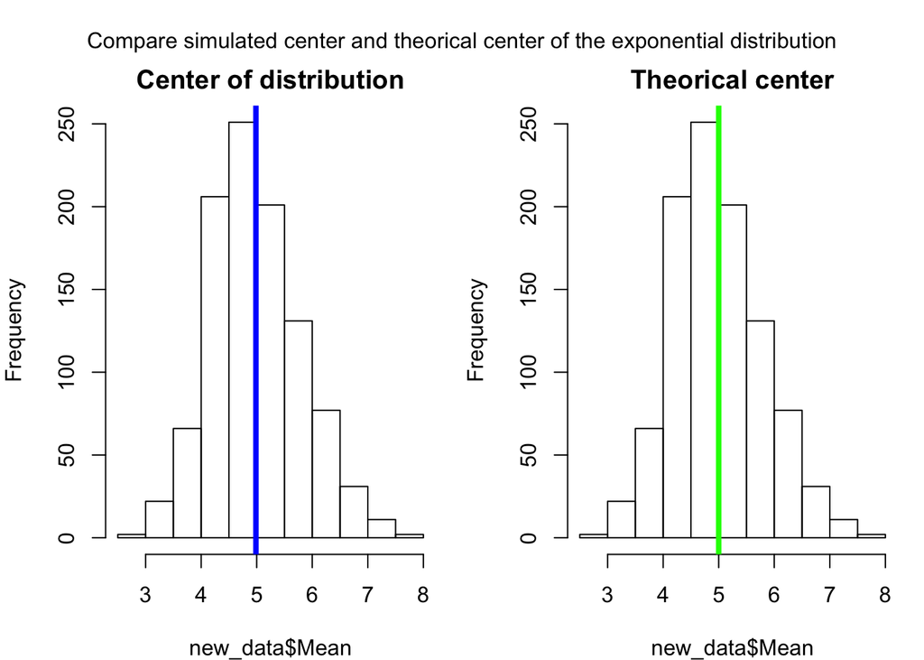

2. Show how variable it is and compare it to the theoretical variance of the distribution.

The table below shows compared variances

[output not shown]

3. Show that the distribution is approximately normal. The previous histogram of the distribution shows that the distribution is approximately normal
4. The coverage of the confidence interval for 1/lambda: X¯±1.96Sn√. (This only needs to be done for the specific value of lambda).

```
## [1] 4.936 5.037
```

### SIMULATIONS (part 2)

1. Load the ToothGrowth data and perform some basic exploratory data analyses

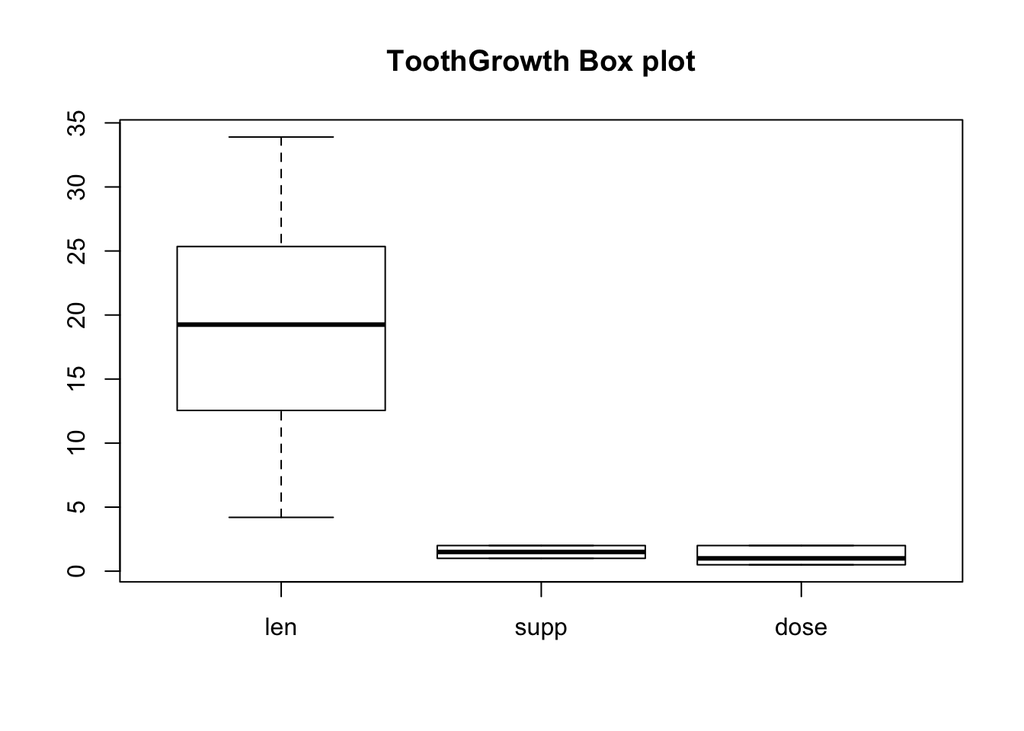

2. Basic summary of the data.

```
##       len       supp         dose
##  Min.   : 4.2   OJ:30   Min.   :0.50
##  1st Qu.:13.1   VC:30   1st Qu.:0.50
##  Median :19.2           Median :1.00
##  Mean   :18.8           Mean   :1.17
##  3rd Qu.:25.3           3rd Qu.:2.00
##  Max.   :33.9           Max.   :2.00
```

3. Confidence intervals and hypothesis tests to compare tooth growth by supp and dose.

Confidence intervals and hypothesis tests to compare tooth growth by supp = VC and dose = 0.5 with supp = VC and dose = 1.0“)

```
##
##  One Sample t-test
##
## data:  vc05 - vc1
## t = -6.136, df = 9, p-value = 0.0001715
## alternative hypothesis: true mean is not equal to 0
## 95 percent confidence interval:
##  -12.03  -5.55
## sample estimates:
## mean of x
##     -8.79
```

4. State your conclusions and the assumptions needed for your conclusions.

**Conclusion**: Confidence intervals and hypothesis tests to compare tooth growth by supp = VC and dose = 0.5 with supp = VC and dose = 1.0 shows a small p-value so means are differents.